# Exporing Social Media Data

In an effort to understand the effects social media has on users, we have decided to explore social media and how marketing tactics affect spending on popular social media sites as well as it’s over all reception by users. This is important as it better informs users of strategies used by sites to lure users into spending as well as allowing for the marketers themselves too see how effectively they are marketing on certain platforms to different demographics of consumers. In this project we have successfully found data on [data.world](https://data.world/). The datasets we chose from data.world was collected via survey on an app known as “Whatsgoodly”.

## Data Summary

The first dataset we used included 6 different columns that addressed different pieces of information about each individual surveyed. There were a total of 2676 of people who responded to the survey. The survey asked the following question: What social platform has influenced your online shopping most? Respondents had the following answers: Facebook, Instagram, Snapchat, Twitter, None. The survey also categorized users into different demographics such as Mobile, Web, Gender, University, Custom, and other groupings allowing us to extrapolate different trends based on these demographics.

The second dataset we have analyzed has 6 different columns with a total of 10427 survey participants. This survey inquired the following: What do you think when an influencer is obviously selling a product?, What social platform has influenced your online shopping most?, What is the most important trait when defining an influencer?, Who are your favorite people to follow online?, Does it annoy you when popular social media accounts endorse products or services?, What do you consider an influencer? The individuals surveyed responded to these inquiries along with demographic information exactly the same as the dataset above such as Mobile, Web, Gender, University, Custom.

## Gender and Spending habits

The following table allows us to gain insight on spending habits by gender. The table shows the count and percentage of each gender that found each social media platform most influential to their shopping experiences. Based on this information, those who wish to find trends and ideas for items based on their gender identity can refer to those popular social media sites. Gender based grouping can also be used in a marketing perspective as marketers are most likely to advertise heavily on sites that have the most influence on certain genders based on the products they sell. This allows us, to then question and inquire further about how advertisers change their tactics based on such demographic information and also wonder why certain groups prefer certain social media platforms.

Based on the table below, many interesting data points are revealed. In female voters, Instagram seems to be a leading influence while the largest portion of male voters voted that no social media platforms had an influence on their shopping. This shows that women may be more susceptible to advertisements on social media and thus may see far more targeted ads towards them. The table also shows that out of the social medias, instagram had the highest influence in both women and men showing that instagram is a source that wields the most control over shopping and thus shapes trends and habits.

| Gender | Platform w/ Most Shopping Influence | Percentage of Gender | Voter Count |
| --- | --- | --- | --- |
| Female voters | Facebook | 19.9% | 222 |
| Female voters | Instagram | 48% | 535 |
| Female voters | Snapchat | 2.6% | 29 |
| Female voters | Twitter | 5.1% | 57 |
| Female voters | None | 24.3% | 271 |
| Male voters | Facebook | 20.9% | 326 |
| Male voters | Instagram | 24.3% | 380 |
| Male voters | Snapchat | 3.6% | 56 |
| Male voters | Twitter | 7.8% | 122 |
| Male voters | None | 43.4% | 678 |

## Opinions on Social Media Marketing

As mentioned above, one of the questions asked in the Whatsgoodly surveys was “What do you think when an influencer is obviously selling a product?”. We categorized the answers so that their responses were categorized as positive, negative, or neutral. This allowed us to make observations on how different demographics felt about social media marketing.

We started by looking at the overall opinion of social media marketing. Below is a pie chart that shows this distribution according to the surveys.

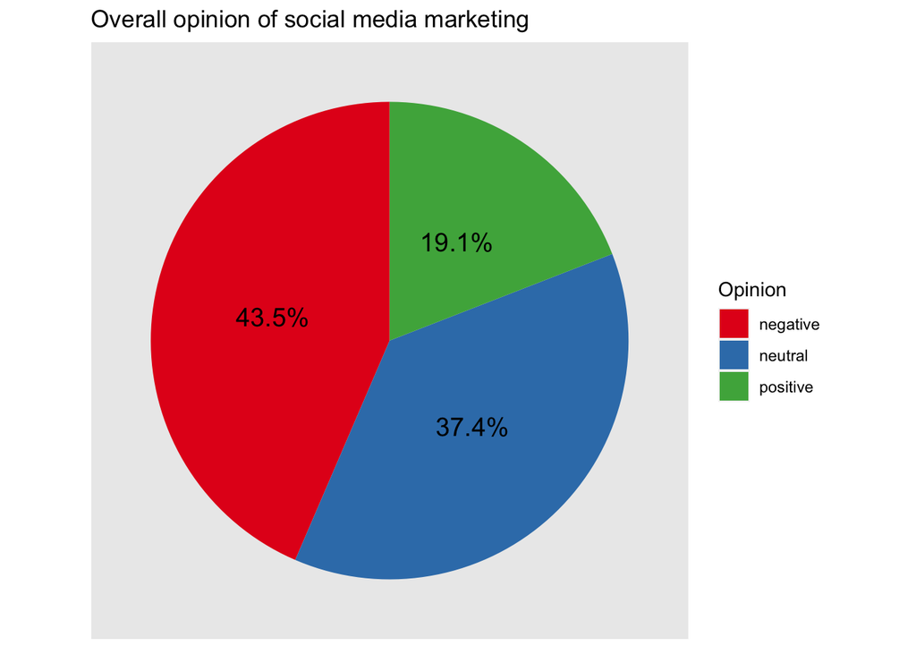

We thought that a pie chart was an effective way of visualizing the distribution because we found that there was a distinct enough difference in count between the three groups. This was assisted by the easily readable percentages within the sections. As seen in the chart, most people that took the survey had a negative or neutral opinion on social media marketing, with almost half of the survey takers having a negative reaction to ads.

We took a deeper dive into the question and looked at how different economic classes felt about social media marketing.

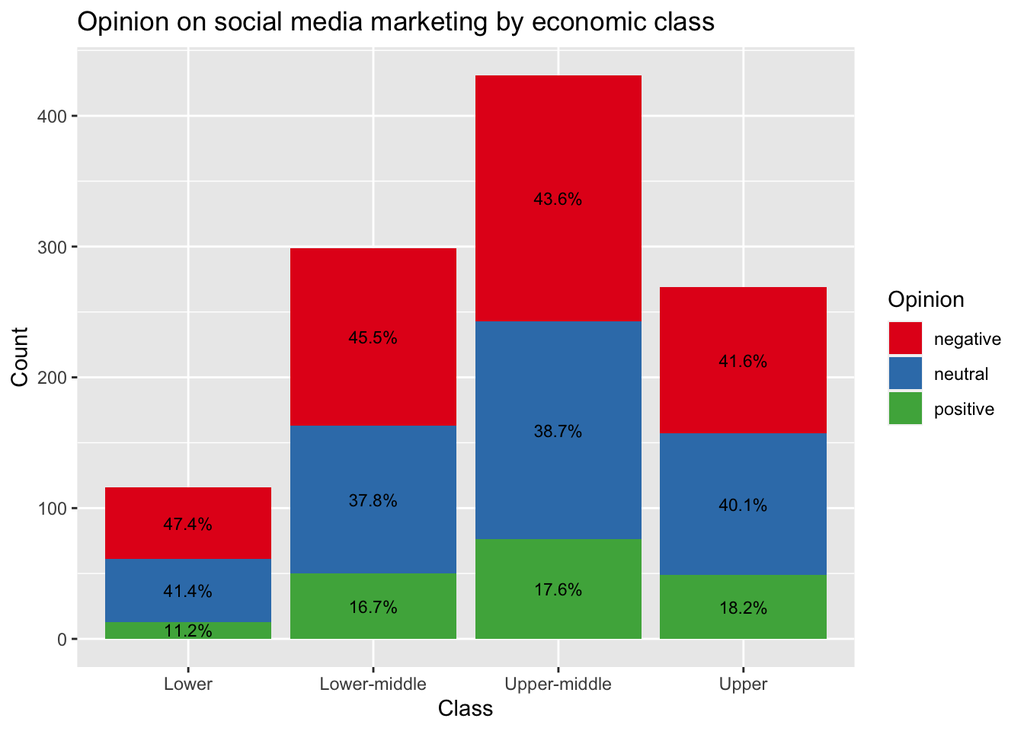

We thought that a stacked bar chart was an effective way of visualizing the opinion counts because there was an easy way to show the amount of people in each category. Although there were significantly differing amounts of respondents in each category, the percentages in each economic class stay roughly the same. They are also very similar to the overal percentages shown in the previous pie chart.

## Effectiveness

To effectively understand how social media marketing affects user interaction, we knew we had to figure out which platforms had the most effective ads. The pie chart below shows the distribution of answers to the Whatsgoodly survey question on which platform has influenced their online shopping.

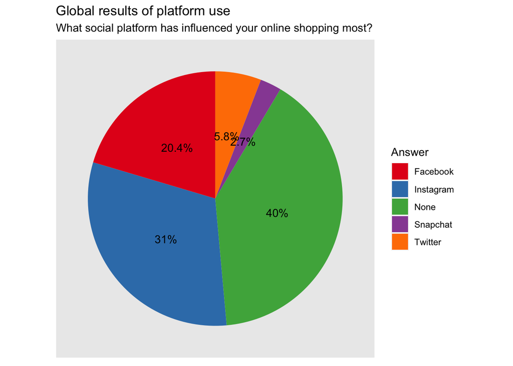